# EDA Project

This is the R Notebook for the project from Sifeng (Daniel) XU, student ID 24525844 for unit *CITS4009 Computation Data Analysis*. It demonstrates the process and findings of EDA and ML based on the **Countries and Death Causes** dataset. Link to the video demo of my shiny app: https://youtu.be/gEgNz4DDMIM.

### Basic information of the data

```r
data.frame(
  columeID = col(df)[1,],
  variables = names(df),
  class = sapply(df, typeof),
  first_values = sapply(df, function(x) paste0(head(x), collapse = ', ')),
  row.names = NULL) |>
kable()
```

| columeID | variables | class | first_values |
| --- | --- | --- | --- |
| 1 | Entity | character | Afghanistan, Afghanistan, Afghanistan, Afghanistan, Afghanistan, Afghanistan |
| 2 | Code | character | AFG, AFG, AFG, AFG, AFG, AFG |
| 3 | Year | integer | 1990, 1991, 1992, 1993, 1994, 1995 |
| 4 | Outdoor.air.pollution | integer | 3169, 3222, 3395, 3623, 3788, 3869 |
| 5 | High.systolic.blood.pressure | integer | 25633, 25872, 26309, 26961, 27658, 28090 |
| 6 | Diet.high.in.sodium | integer | 1045, 1055, 1075, 1103, 1134, 1154 |
| 7 | Diet.low.in.whole.grains | integer | 7077, 7149, 7297, 7499, 7698, 7807 |
| 8 | Alochol.use | integer | 356, 364, 376, 389, 399, 406 |
| 9 | Diet.low.in.fruits | integer | 3185, 3248, 3351, 3480, 3610, 3703 |
| 10 | Unsafe.water.source | integer | 3702, 4309, 5356, 7152, 7192, 8378 |
| 11 | Secondhand.smoke | integer | 4794, 4921, 5279, 5734, 6050, 6167 |
| 12 | Low.birth.weight | integer | 16135, 17924, 21200, 23795, 24866, 25534 |
| 13 | Child.wasting | integer | 19546, 20334, 22895, 27002, 29205, 30943 |
| 14 | Unsafe.sex | integer | 351, 361, 378, 395, 410, 422 |
| 15 | Diet.low.in.nuts.and.seeds | integer | 2319, 2449, 2603, 2771, 2932, 3049 |
| 16 | Household.air.pollution.from.solid.fuels | integer | 34372, 35392, 38065, 41154, 43153, 44024 |
| 17 | Diet.low.in.Vegetables | integer | 3679, 3732, 3827, 3951, 4075, 4153 |
| 18 | Low.physical.activity | integer | 2637, 2652, 2688, 2744, 2805, 2839 |
| 19 | Smoking | integer | 5174, 5247, 5363, 5522, 5689, 5801 |
| 20 | High.fasting.plasma.glucose | integer | 11449, 11811, 12265, 12821, 13400, 13871 |
| 21 | Air.pollution | integer | 37231, 38315, 41172, 44488, 46634, 47566 |
| 22 | High.body.mass.index | integer | 9518, 9489, 9528, 9611, 9675, 9608 |
| 23 | Unsafe.sanitation | integer | 2798, 3254, 4042, 5392, 5418, 6313 |
| 24 | No.access.to.handwashing.facility | integer | 4825, 5127, 5889, 7007, 7421, 7896 |
| 25 | Drug.use | integer | 174, 188, 211, 232, 247, 260 |
| 26 | Low.bone.mineral.density | integer | 389, 389, 393, 411, 413, 417 |
| 27 | Vitamin.A.deficiency | integer | 2016, 2056, 2100, 2316, 2665, 3070 |
| 28 | Child.stunting | integer | 7686, 7886, 8568, 9875, 11031, 11973 |
| 29 | Discontinued.breastfeeding | integer | 107, 121, 150, 204, 204, 233 |
| 30 | Non.exclusive.breastfeeding | integer | 2216, 2501, 3053, 3726, 3833, 4124 |
| 31 | Iron.deficiency | integer | 564, 611, 700, 773, 812, 848 |

```r
summary(df) |> kable()
```

|  | Entity | Code | Year | Outdoor.air.pollution | High.systolic.blood.pressure | Diet.high.in.sodium | Diet.low.in.whole.grains | Alochol.use | Diet.low.in.fruits | Unsafe.water.source | Secondhand.smoke | Low.birth.weight | Child.wasting | Unsafe.sex | Diet.low.in.nuts.and.seeds | Household.air.pollution.from.solid.fuels | Diet.low.in.Vegetables | Low.physical.activity | Smoking | High.fasting.plasma.glucose | Air.pollution | High.body.mass.index | Unsafe.sanitation | No.access.to.handwashing.facility | Drug.use | Low.bone.mineral.density | Vitamin.A.deficiency | Child.stunting | Discontinued.breastfeeding | … |
| --- | --- | --- | --- | --- | --- | --- | --- | --- | --- | --- | --- | --- | --- | --- | --- | --- | --- | --- | --- | --- | --- | --- | --- | --- | --- | --- | --- | --- | --- | --- |
|  | Length:6840 | Length:6840 | Min. :1990 | Min. : 0 | Min. : 2 | Min. : 0.0 | Min. : 0.0 | Min. : 0.0 | Min. : 0.0 | Min. : 0.0 | Min. : 1 | Min. : 0 | Min. : 0 | Min. : 0 | Min. : 0 | Min. : 0 | Min. : 0.0 | Min. : 0.0 | Min. : 1 | Min. : 3 | Min. : 0 | Min. : 2 | Min. : 0 | Min. : 0 | Min. : 0 | Min. : 0 | Min. : 0.0 | Min. : 0.0 | Min. : 0.00 | … |
|  | Class :character | Class :character | 1st Qu.:1997 | 1st Qu.: 434 | 1st Qu.: 1828 | 1st Qu.: 137.0 | 1st Qu.: 273.8 | 1st Qu.: 263.8 | 1st Qu.: 144.0 | 1st Qu.: 7.0 | 1st Qu.: 209 | 1st Qu.: 123 | 1st Qu.: 26 | 1st Qu.: 97 | 1st Qu.: 27 | 1st Qu.: 32 | 1st Qu.: 109.0 | 1st Qu.: 92.0 | 1st Qu.: 894 | 1st Qu.: 1178 | 1st Qu.: 816 | 1st Qu.: 918 | 1st Qu.: 3 | 1st Qu.: 19 | 1st Qu.: 31 | 1st Qu.: 43 | 1st Qu.: 0.0 | 1st Qu.: 1.0 | 1st Qu.: 0.00 | … |
|  | Mode :character | Mode :character | Median :2004 | Median : 2101 | Median : 8770 | Median : 969.5 | Median : 1444.0 | Median : 1780.5 | Median : 834.5 | Median : 182.5 | Median : 994 | Median : 1057 | Median : 504 | Median : 619 | Median : 252 | Median : 821 | Median : 590.5 | Median : 521.5 | Median : 4987 | Median : 4966 | Median : 5748 | Median : 3917 | Median : 102 | Median : 221 | Median : 222 | Median : 277 | Median : 2.0 | Median : 41.5 | Median : 4.00 | … |
|  | NA | NA | Mean :2004 | Mean : 84582 | Mean : 224225 | Mean : 40497.2 | Mean : 38691.3 | Mean : 54848.6 | Mean : 23957.8 | Mean : 44086.4 | Mean : 30364 | Mean : 59126 | Mean : 49924 | Mean : 27646 | Mean : 12996 | Mean : 83641 | Mean : 11982.5 | Mean : 16489.1 | Mean : 181958 | Mean : 117554 | Mean : 164752 | Mean : 89870 | Mean : 31522 | Mean : 21800 | Mean : 10285 | Mean : 8182 | Mean : 2471.6 | Mean : 11164.3 | Mean : 431.46 | … |
|  | NA | NA | 3rd Qu.:2012 | 3rd Qu.: 11810 | 3rd Qu.: 40356 | 3rd Qu.: 5169.8 | 3rd Qu.: 6773.2 | 3rd Qu.: 8368.0 | 3rd Qu.: 3104.8 | 3rd Qu.: 5599.2 | 3rd Qu.: 4348 | 3rd Qu.: 10903 | 3rd Qu.: 9765 | 3rd Qu.: 4492 | 3rd Qu.: 1998 | 3rd Qu.: 10870 | 3rd Qu.: 2101.8 | 3rd Qu.: 2820.2 | 3rd Qu.: 23994 | 3rd Qu.: 21639 | 3rd Qu.: 25050 | 3rd Qu.: 17968 | 3rd Qu.: 3854 | 3rd Qu.: 3954 | 3rd Qu.: 1224 | 3rd Qu.: 1232 | 3rd Qu.: 230.2 | 3rd Qu.: 1563.2 | 3rd Qu.: 71.25 | … |
|  | NA | NA | Max. :2019 | Max. :4506193 | Max. :10845595 | Max. :1885356.0 | Max. :1844836.0 | Max. :2441973.0 | Max. :1046015.0 | Max. :2450944.0 | Max. :1304318 | Max. :3033425 | Max. :3430422 | Max. :1664813 | Max. :575139 | Max. :4358214 | Max. :529381.0 | Max. :831502.0 | Max. :7693368 | Max. :6501398 | Max. :6671740 | Max. :5019360 | Max. :1842275 | Max. :1200349 | Max. :494492 | Max. :437884 | Max. :207555.0 | Max. :833449.0 | Max. :33106.00 | … |

```r
head(df) |> kable()
```

| Entity | Code | Year | Outdoor.air.pollution | High.systolic.blood.pressure | Diet.high.in.sodium | Diet.low.in.whole.grains | Alochol.use | Diet.low.in.fruits | Unsafe.water.source | Secondhand.smoke | Low.birth.weight | Child.wasting | Unsafe.sex | Diet.low.in.nuts.and.seeds | Household.air.pollution.from.solid.fuels | Diet.low.in.Vegetables | Low.physical.activity | Smoking | High.fasting.plasma.glucose | Air.pollution | High.body.mass.index | Unsafe.sanitation | No.access.to.handwashing.facility | Drug.use | Low.bone.mineral.density | Vitamin.A.deficiency | Child.stunting | Discontinued.breastfeeding | Non.exclusive.breastfeeding | … |
| --- | --- | --- | --- | --- | --- | --- | --- | --- | --- | --- | --- | --- | --- | --- | --- | --- | --- | --- | --- | --- | --- | --- | --- | --- | --- | --- | --- | --- | --- | --- |
| Afghanistan | AFG | 1990 | 3169 | 25633 | 1045 | 7077 | 356 | 3185 | 3702 | 4794 | 16135 | 19546 | 351 | 2319 | 34372 | 3679 | 2637 | 5174 | 11449 | 37231 | 9518 | 2798 | 4825 | 174 | 389 | 2016 | 7686 | 107 | 2216 | … |
| Afghanistan | AFG | 1991 | 3222 | 25872 | 1055 | 7149 | 364 | 3248 | 4309 | 4921 | 17924 | 20334 | 361 | 2449 | 35392 | 3732 | 2652 | 5247 | 11811 | 38315 | 9489 | 3254 | 5127 | 188 | 389 | 2056 | 7886 | 121 | 2501 | … |
| Afghanistan | AFG | 1992 | 3395 | 26309 | 1075 | 7297 | 376 | 3351 | 5356 | 5279 | 21200 | 22895 | 378 | 2603 | 38065 | 3827 | 2688 | 5363 | 12265 | 41172 | 9528 | 4042 | 5889 | 211 | 393 | 2100 | 8568 | 150 | 3053 | … |
| Afghanistan | AFG | 1993 | 3623 | 26961 | 1103 | 7499 | 389 | 3480 | 7152 | 5734 | 23795 | 27002 | 395 | 2771 | 41154 | 3951 | 2744 | 5522 | 12821 | 44488 | 9611 | 5392 | 7007 | 232 | 411 | 2316 | 9875 | 204 | 3726 | … |
| Afghanistan | AFG | 1994 | 3788 | 27658 | 1134 | 7698 | 399 | 3610 | 7192 | 6050 | 24866 | 29205 | 410 | 2932 | 43153 | 4075 | 2805 | 5689 | 13400 | 46634 | 9675 | 5418 | 7421 | 247 | 413 | 2665 | 11031 | 204 | 3833 | … |
| Afghanistan | AFG | 1995 | 3869 | 28090 | 1154 | 7807 | 406 | 3703 | 8378 | 6167 | 25534 | 30943 | 422 | 3049 | 44024 | 4153 | 2839 | 5801 | 13871 | 47566 | 9608 | 6313 | 7896 | 260 | 417 | 3070 | 11973 | 233 | 4124 | … |

A first glance of data shows 31 columns which consists of 3 non-numerical data:

- countries’ full name
- short country code
- year of measurements (1990-2019)

the rest is numerical data showing how many deaths from each cause, each year and each country/region. Some countries are counted together such as *G20, OECD Countries, South-East Asia Region* and *Western Passific Region*. Also, some measured variables look similar such as *Outdoor.air.pollution, Household.air.pollution.from.solid.fuels* and *Air.pollution*.

To give an impression what the dataset looks like, a snippet shows 6 countries and their deaths count from several causes in 2010.

```r
df_2010 <- df[df['Year']==2010,
  c('Entity', 'Code', 'Outdoor.air.pollution','Child.wasting', 'Smoking', 'Drug.use')]
countries <- c('Afghanistan', 'Morocco', 'Nigeria', 'Australia', 'Belgium', 'Congo')
snippet <- subset(df_2010, Entity %in% countries)
names(snippet)[1] <- 'Country'
print(snippet)
```

```
##          Country Code Outdoor.air.pollution Child.wasting Smoking Drug.use
## 21   Afghanistan  AFG                  5344         19135    7340      463
## 321    Australia  AUS                  1644           130   17852     1880
## 561      Belgium  BEL                  4983           282   19886      784
## 1251       Congo  COG                  1188          2222    1006      148
## 3891     Morocco  MAR                 19524          3262   17038      856
## 4191     Nigeria  NGA                 47250        262186   16448    10955
```

### Histogram for single death cause

First check the data range by histogram. Variables that are linked to environment such as outdoor and household air quality tend to cause more deaths. This may prove that the long-term influence of poor air quality, which often sustains through a longer period, can kill many people living in that area/region.

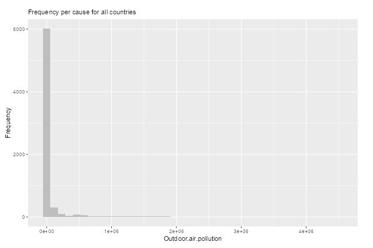

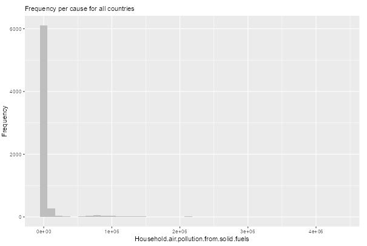

In contrast, causes such as *iron deficiency* and *vitamin A deficiency* lead to far less mortalities worldwide. Probably lack of iron or vitamin A alone is not too critical to the survival of most people.

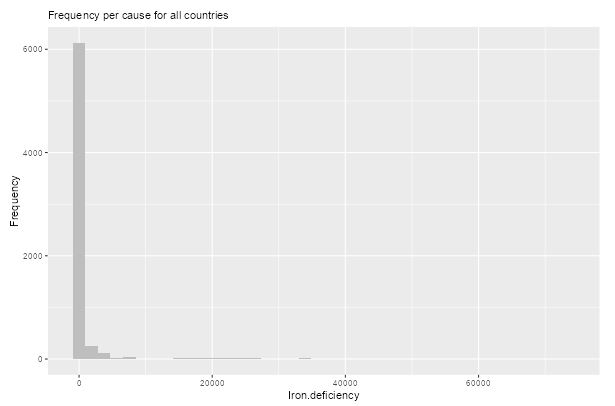

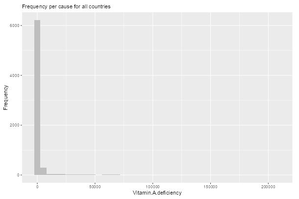

Across all variables, a fact is that high value of mortality does not appear often as most values seem to stay close to the lower boundary. Note a spike near zero for all example figures.

### Boxplot single

After comparing different countries with boxplot, it is noticeable that developed countries usually have less mortalities than developing countries in causes related to poor hygiene (e.g. water quality, unsafe sanitation and no access to hand washing facility).

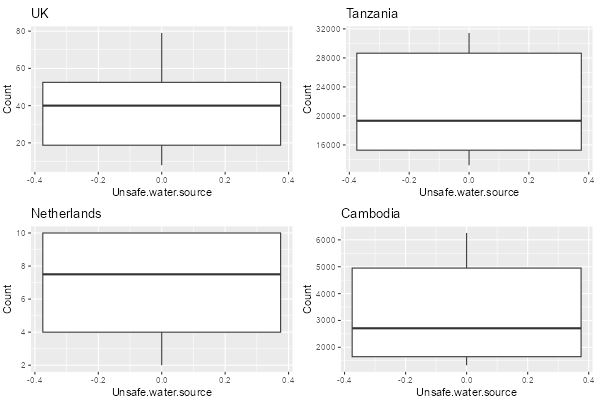

Unsafe water source

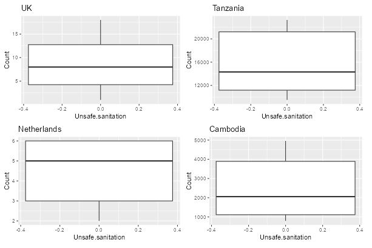

Unsafe sanitation

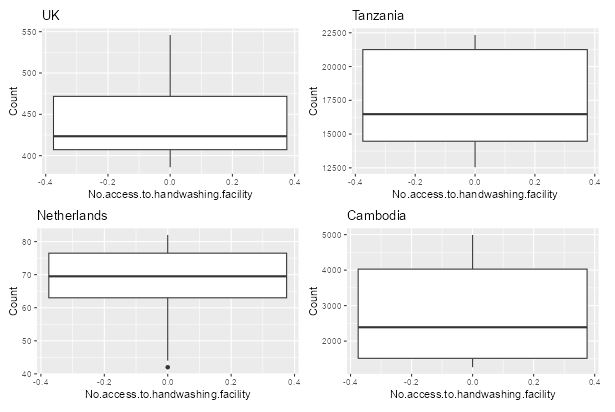

No access to handwashing facility

Two pairs of countries are selected here as examples between *UK* and *Tanzania*, as well as *Netherlands* and *Cambodia*. The reason why they are compared to each other is because they share similar population according to [Worldometers](https://www.worldometers.info/world-population/population-by-country/).

### Trend comparison

Line graph shows the trend of certain causes from 1990 to 2019. Comparison between countries shows interesting facts. Alcohol use seems to be more detrimental to people’s health in recent years in both developed and developing countries selected in previous section.

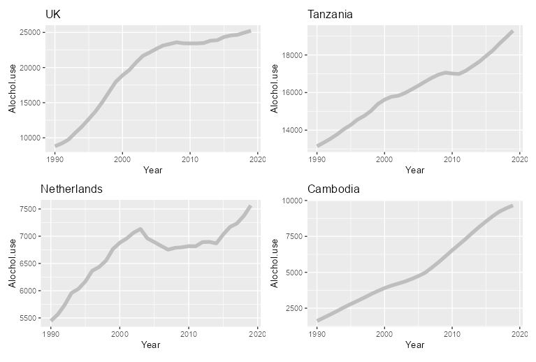

On the other hand, outdoor air pollution appears to become less harmful in western Europe than in Africa or Asia. This may have to do with the progress of industrialisation which leads to air pollution. In other words, Europe was almost at the end of it around the turn of the century. That is when they paid more attention to the environmental impacts. While certain areas in Africa and Asia just started to industrialise themselves. That is why the air quality got worse and worse in this period there.

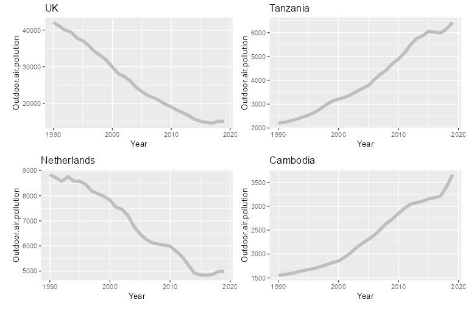

### Bar chart

Drug use seems to have serious impact in both rich and poor areas. In the figure below, far more people ended their life in India and the USA due to drug use than the whole African Region in 2010. European region is not much better as they ranked the third in this set of comparison worldwide.

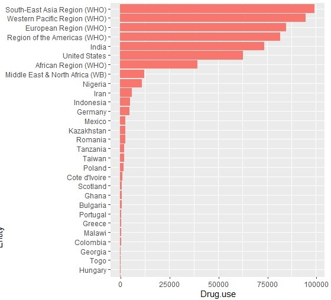

### Correlation between variables

When comparing multiple variables, it is clear that diet related death causes are positive linear for African region. This may indicate the food security issue in this area. On the other hand, this correlation seems less obvious for North America where the general public have much more dietary options.

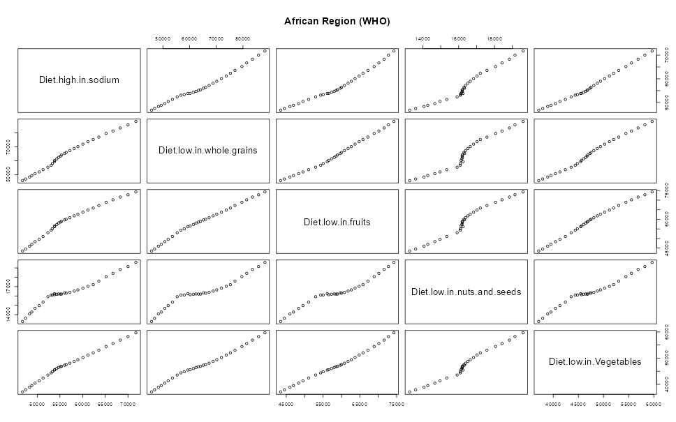

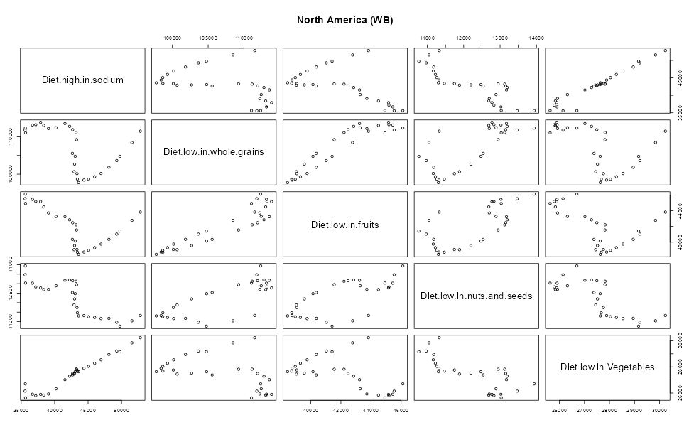

Smooth curve and jittering points shows drug use and unsafe sex clustering when sex fatality value is low. Once the value grows further they seem less correlated.

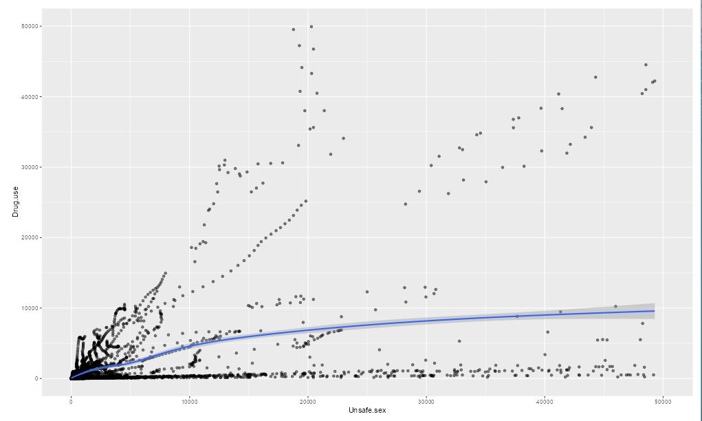

### Missing values and anomolies

All numerical variables are checked against: *NA, null, zeros* and *negative values*.

```r
numericVars <- names(df[, -c(1:3)]) # ignore Entity, Code and Year columns
df_num <- df[numericVars]

print(sum(is.na(df_num)))
```

```
## [1] 0
```

```r
print(sum(is.null(df_num)))
```

```
## [1] 0
```

```r
print(sum(df_num < 0))
```

```
## [1] 0
```

```r
print(sum(df_num == 0))
```

```
## [1] 12108
```

Currently there is no NA’s in the dataset, neither are there any negative values. So this dataset looks quite clean. In addition, there are zero values, which may indicate that either no one died of that specific cause in a country in a specific year, or they are missing values. Although it is possible to treat zero’s as NA’s and replace them with e.g. median or mean, doing this will overwrite all the zero’s which are truly reflecting zero mortality. Therefore, in this project we will keep zero’s as-is.

When checking the first three columns it shows that *Code* are empty in 690 rows. These appear to be specific to aggregated regions e.g. *OECD Countries* or regions within a country without a valid country code e.g. *Scotland*.

```r
count_empty <- function(data){
  count_missing <- function(data){
    sapply(data, FUN=function(col) sum(col == ''))
  }
  nullcounts <- count_missing(data)
  hasNull = which(nullcounts > 0)
  nullcounts[hasNull]
}

print(count_empty(df))
```

```
## Code
##  690
```

```r
empty_rows <- df[df$Code == '', ]
print(empty_rows[sample(nrow(empty_rows), size = 6, replace = F), c(1:6)])
```

```
##                               Entity Code Year Outdoor.air.pollution
## 6632          World Bank High Income      1991                494988
## 3723 Middle East & North Africa (WB)      1992                149067
## 1999      Europe & Central Asia (WB)      2008                563551
## 3157  Latin America & Caribbean (WB)      1996                119008
## 6700  World Bank Lower Middle Income      1999                894774
## 3168  Latin America & Caribbean (WB)      2007                133885
##      High.systolic.blood.pressure Diet.high.in.sodium
## 6632                      2109771              248909
## 3723                       305788               12362
## 1999                      2388517              290870
## 3157                       409378               59692
## 6700                      2312557              303494
## 3168                       515127               68960
```

To make it easier to understand the sections below we rename *Entity* to *Country*. Also, because we will merge external data into this dataset based on country code, the aggregated regions will not be receiving any match. Therefore we would like to drop them now and keep only data per country for further study.

```r
colnames(df)[1] <- "Country"
df <- df[df$Code != '', ]
```

### Classfication

We feel that the mortality count alone may not tell us much. So we would like to include country’s total population to study death rates. Now we are going to merge the dataset as provided from [World Bank](https://data.worldbank.org/indicator/NY.GDP.PCAP.CD), and check missing values immediately.

```r
library(reshape2)

# merge total population
popl <- read.table('./API_SP.POP.TOTL_DS2_en_csv_v2_31753/API_SP.POP.TOTL_DS2_en_csv_v2_31753.csv',header=T, sep=',')
colnames(popl) <- gsub("^X", "", colnames(popl))

popl <- popl[, c('Country.Code', years)]
popl_df <- melt(popl, id.vars = "Country.Code", variable.name = "Year", value.name = "total.population")
popl_df$Year <- as.numeric(as.character(popl_df$Year))
df_merged <- merge(df, popl_df, by.x = c("Code", "Year"), by.y = c("Country.Code", "Year"), all.x = TRUE)

df_merged <- df_merged[, c(1:3, ncol(df_merged)-1, ncol(df_merged), 4:(ncol(df_merged)-2))]

nacount <- count_nas(df_merged)
print(nacount)
```

```
## total.population
##              150
```

```r
nas_df_merged <- df_merged[is.na(df_merged$total.population),]
nas_df_merged[sample(nrow(nas_df_merged), 6), 1:5]
```

```
##          Code Year      Country Iron.deficiency total.population
## 5652      TWN 2001       Taiwan               3               NA
## 1179      COK 1998 Cook Islands               0               NA
## 4214 OWID_WRL 2003        World           62770               NA
## 1183      COK 2002 Cook Islands               0               NA
## 5667      TWN 2016       Taiwan               3               NA
## 4219 OWID_WRL 2008        World           56450               NA
```

It appears that some islands and *World* (containing total number for the whole world) are also included which results in 150 NA’s when integrating with total population. This is only 2.4390244% of all dataset. Since we are only interested in studying individual countries it is alright to drop them.

```r
df_merged <- setdiff(df_merged, nas_df_merged)

# Our new dataset looks like:
df_merged[sample(nrow(df_merged), 6), 1:5]
```

```
##      Code Year               Country Iron.deficiency total.population
## 3230  LUX 2009            Luxembourg               0           497783
## 4686  SEN 1995               Senegal             387          8632681
## 4838  SMR 1997            San Marino               0            25596
## 2897  KNA 2006 Saint Kitts and Nevis               0            46874
## 1616  EGY 2015                 Egypt             126         97723799
## 5301  TJK 2010            Tajikistan              11          7621779
```

Now that total population is merged and tidied up, we would like to know which death causes have large impact worldwide. Since the absolute number of mortality can vary largely depending on the population of a country, a better measurement is the percentage of each death cause, with respect to the total casualties in that row. For example, if the total number of deaths in a year for country X is 1000 where 10 people died from outdoor air pollution, then $outdoor.air.pollution.rate=0.01$

We will first create a rate to count the percentage of each specific casualty cause. Then visualise the stats with boxplot to see the major players worldwide. Also *Country* and *Year* will be converted to factor.

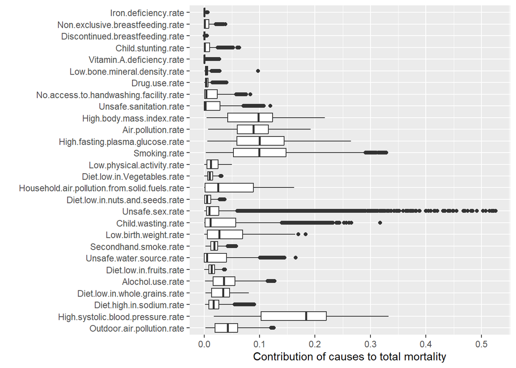

```r
df_merged$Country <- as.factor(df_merged$Country)
df_merged$Year <- as.factor(df_merged$Year)

df_merged$total.mortality <- rowSums(df_merged[numericVars])

for (col in numericVars) {
    df_merged[paste0(col, ".rate")] <- df_merged[col] / df_merged['total.mortality']
}

rateVars <- grep("\\.rate$", names(df_merged), value = TRUE)

figRateAll <- ggplot(stack(df_merged[rateVars])) + geom_boxplot(mapping = aes(x = ind, y = values)) + labs(x ='', y='Contribution of causes to total mortality') + coord_flip()
# count the death rate of all causes with respect to the total population
df_merged$Death.rate <- (df_merged$total.mortality / df_merged$total.population)

print(figRateAll)
```

### Single variable prediction

It seems high blood pressure, smoking, high glucose rate and high BMI (obesity) are the top reasons to people’s death. Now we would like to see what causes high death rate to a country. The rate is high (True) if it is over the median rate worldwide. This binary variable holds the ground truth to check against the prediction later.

Another reason to make extra binary variables is because so far there are only years and countries which can be converted to factors. We would like to combine a couple of extra categorical variables in our prediction. Variable *Code* is less self-explanatory than Country and therefore we will remove it.

Now it is time to separate the data into training (81%), calibration(9%) and test (10%) data.

```r
df_merged$Code <- NULL

outcome <- c('Death.rate.high') # Smoking.kills.more, sodium.over.median
pos <- TRUE # positive value

df_merged <- df_merged |>
  mutate(
    Death.rate.high = (Death.rate > median(Death.rate)),
    Unsafe.sex.over.median = (Unsafe.sex.rate > median(Unsafe.sex.rate)),
    Smoking.over.median = (Smoking.rate > median(Smoking.rate)),
    Blood.pressure.over.median = (High.systolic.blood.pressure.rate < median(High.systolic.blood.pressure.rate))
)

d <- df_merged

set.seed(729375)
d$rgroup <- runif(dim(d)[1])
dTrainAll <- subset(d, rgroup<=0.9)
dTest <- subset(d, rgroup>0.9)

# split dTrainAll into a training set and a validation (or calibration) set
useForCal <- rbinom(n=dim(dTrainAll)[1], size=1, prob=0.1)>0
dCal <- subset(dTrainAll, useForCal)
dTrain <- subset(dTrainAll, !useForCal)
```

The next step is to go through the categorical variables and see which one has the best prediction chance. Here the null model is saying the chance of our outcome variable being True will be the overall proportion of True values in the whole dataset, regardless what input it receives. Our goal is to find the single variable(s) that can help predict the result better than the null model does.

```r
# names of columns that are categorical type and numerical type
vars <- setdiff(colnames(dTrainAll), c(outcome, 'rgroup'))
catVars <- vars[sapply(d[,vars], class) %in% c('character', 'logical',  'factor')]

mkPredC <- function(outCol, varCol, appCol) {
  pPos <- sum(outCol==pos)/length(outCol)
  naTab <- table(as.factor(outCol[is.na(varCol)]))
  pPosWna <- (naTab/sum(naTab))[pos]
  vTab <- table(as.factor(outCol), varCol)
  pPosWv <- (vTab[pos,]+1.0e-3*pPos)/(colSums(vTab)+1.0e-3)
  pred <- pPosWv[appCol]
  pred[is.na(appCol)] <- pPosWna
  pred[is.na(pred)] <- pPos
  pred
}

# now go through all the categorical variables in the `catVars` vector
# and perform the predictions.
for (v in catVars) {
  pi <- paste('pred.', v, sep='')
  dTrain[,pi] <- mkPredC(dTrain[,outcome], dTrain[,v], dTrain[,v])
  dCal[,pi] <- mkPredC(dTrain[,outcome], dTrain[,v], dCal[,v])
  dTest[,pi] <- mkPredC(dTrain[,outcome], dTrain[,v], dTest[,v])
}

# Define a function to compute log likelihood so that we can reuse it.
logLikelihood <- function(ypred, ytrue) {
  sum(ifelse(ytrue, log(ypred), log(1-ypred)), na.rm=T)
}

# Compute the likelihood of the Null model on the calibration
pred.Null <- sum(dTrain[,outcome]==pos)/nrow(dTrain)
logNull <- logLikelihood(sum(dCal[,outcome]==pos)/nrow(dCal), dCal[,outcome]==pos)
cat("The log likelihood of the Null model is:", logNull)
```

```
## The log likelihood of the Null model is: -368.6941
```

```r
selCatVars <- c()
minDrop <- -3

for (v in catVars) {
  pi <- paste('pred.', v, sep='')
  logPred <- logLikelihood(dCal[,pi], dCal[,outcome]==pos)
  cat(sprintf("%6s, log likelihood: %g\n", v, logPred))
  devDrop <- 2*(logPred - logNull)
  if (devDrop >= minDrop) {
    cat(sprintf("%6s, deviance reduction: %g\n", v, devDrop))
    selCatVars <- c(selCatVars, pi)
  }
}
```

```
##   Year, log likelihood: -375.85
## Country, log likelihood: -1061.83
## Unsafe.sex.over.median, log likelihood: -368.743
## Unsafe.sex.over.median, deviance reduction: -0.0979358
## Smoking.over.median, log likelihood: -368.742
## Smoking.over.median, deviance reduction: -0.0956009
## Blood.pressure.over.median, log likelihood: -368.782
## Blood.pressure.over.median, deviance reduction: -0.175797
```

```r
devDrop <- 2*(logLikelihood(dCal[,outcome], dCal[,outcome]==pos) - logNull)
cat(sprintf("To compare, deviance reduction of the variable that we want to predict %6s is: %g\n", outcome, devDrop))
```

```
## To compare, deviance reduction of the variable that we want to predict Death.rate.high is: 737.388
```

After checking the log likelihood and deviance reduction, no categorical or binary variables are doing a great job. Let is check how they perform in the ROC curve.

```r
library(ROCit)

# colour_id 1-7 are: black,red,green,blue,cyan,purple,gold
plot_roc <- function(predcol, outcol, colour_id=2, overlaid=F) {
  ROCit_obj <- rocit(score=predcol, class=outcol==pos)
  par(new=overlaid)
  plot(ROCit_obj, col = c(colour_id, 1),
  legend = FALSE, YIndex = FALSE, values = FALSE)
}

print(selCatVars)
```

```
## [1] "pred.Unsafe.sex.over.median"     "pred.Smoking.over.median"
## [3] "pred.Blood.pressure.over.median"
```

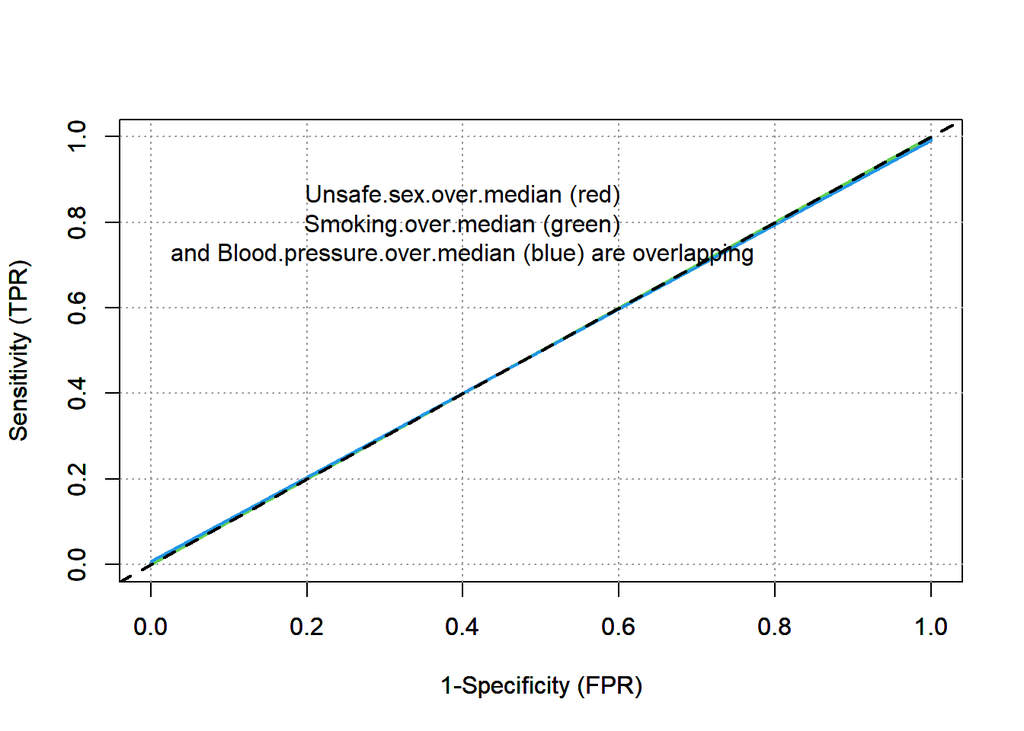

```r
plot_roc(dCal[[selCatVars[1]]], dCal[,outcome]) #First variable is red
plot_roc(dCal[[selCatVars[2]]], dCal[,outcome], colour_id=3, overlaid=T) # Second variable is green
plot_roc(dCal[[selCatVars[3]]], dCal[,outcome], colour_id=4, overlaid=T)
text(x = 0.4, y = 0.8, label = paste('Unsafe.sex.over.median (red)', 'Smoking.over.median (green)', "and Blood.pressure.over.median (blue) are overlapping", sep='\n'))
```

Their AUC values are not higher than the null model. This is the confirmation to their poor performance in log likelihood and deviance reduction.

Now we are going to see if numerical variables can do better. We will use all num vars for prediction of Death.rate.high.

```r
numericVars <- vars[sapply(d[,vars], class) %in% c('numeric','integer')]

# get all percentage / rate variables
rateVars <- grep("\\.rate$", numericVars, value = TRUE)

mkPredN <- function(outCol, varCol, appCol) {
  cuts <- unique(as.numeric(
    quantile(varCol, probs=seq(0, 1, 0.1), na.rm=T)))
  varC <- cut(varCol, cuts)
  appC <- cut(appCol, cuts)
  mkPredC(outCol, varC, appC)
}

# now go through all numerical variables in the `numericVars` vector and perform the predictions.
for (v in numericVars) {
  pi <- paste('pred.', v, sep='')
  dTrain[,pi] <- mkPredN(dTrain[,outcome], dTrain[,v], dTrain[,v])
  dTest[,pi] <- mkPredN(dTrain[,outcome], dTrain[,v], dTest[,v])
  dCal[,pi] <- mkPredN(dTrain[,outcome], dTrain[,v], dCal[,v])
}

# selNumVars is a vector that keeps the names of the top performing numerical variables.
selNumVars <- c()
minDrop <- 0

for (v in numericVars) {
  pi <- paste('pred.', v, sep='')
  logPred <- logLikelihood(dCal[,pi], dCal[,outcome]==pos)

  devDrop <- 2*(logPred - logNull)
  if (devDrop >= minDrop) {
    cat(sprintf("%6s, deviance reduction: %g\n", v, devDrop))
    selNumVars <- c(selNumVars, pi)
  }
}
```

```
## total.population, deviance reduction: 4.09065
## Unsafe.sanitation, deviance reduction: 58.1402
```

The pred.total.population, pred.Unsafe.sanitation seems to be useful in reducing deviance, especially pred.Unsafe.sanitation which is doing extremely well. Let us see how it performs using AUC in calibration and test data set. We will also check the result with 100 fold cross-validation.

```r
library(ROCR)
calcAUC <- function(ypred, ytrue) {
    perf <- performance(prediction(ypred, ytrue), 'auc')
    as.numeric(perf@y.values)
}

# selVars <- c(selCatVars, selNumVars)
selVars <- c()

## Performance of the top performing single variables on the test set:
for(v in c(selCatVars, selNumVars)) {
  pi <- v
  aucTrain <- calcAUC(dTrain[,pi], dTrain[,outcome])
  if (aucTrain > 0.52) {
    selVars <- c(selVars, pi)
    aucCal <- calcAUC(dCal[,pi], dCal[,outcome])
    print(sprintf(
      "%s: trainAUC: %4.3f; calibrationAUC: %4.3f",
      pi, aucTrain, aucCal))
  }
}
```

```
## [1] "pred.total.population: trainAUC: 0.533; calibrationAUC: 0.571"
## [1] "pred.Unsafe.sanitation: trainAUC: 0.558; calibrationAUC: 0.545"
```

```r
# Run 100-fold cross validation
original_vars <- character() #sub("^pred\\.", "", selVars)
# cat("Performance of the top performing single variables on the test set:")

for (v in selVars) {
  # retrieve the original variable name (character location 6 onward)
  orig_v <- substring(v, 6)
  original_vars <- c(original_vars, orig_v)
  cat(sprintf("In dTest Variable %6s: AUC = %g\n", orig_v, calcAUC(dTest[,v], dTest[,outcome]==pos)))
}
```

```
## In dTest Variable total.population: AUC = 0.529488
## In dTest Variable Unsafe.sanitation: AUC = 0.493684
```

```r
for (var in original_vars) {
  aucs <- rep(0,100)
  for (rep in 1:length(aucs)) {
    useForCalRep <- rbinom(n=nrow(dTrainAll), size=1, prob=0.1) > 0
    predRep <- mkPredC(dTrainAll[!useForCalRep, outcome],
    dTrainAll[!useForCalRep, var],
    dTrainAll[useForCalRep, var])
    aucs[rep] <- calcAUC(predRep, dTrainAll[useForCalRep, outcome])
  }
  print(sprintf("In dTrainAll %s: mean AUC: %4.3f; sd: %4.3f", var, mean(aucs), sd(aucs)))
}
```

```
## [1] "In dTrainAll total.population: mean AUC: 0.500; sd: 0.002"
## [1] "In dTrainAll Unsafe.sanitation: mean AUC: 0.496; sd: 0.027"
```

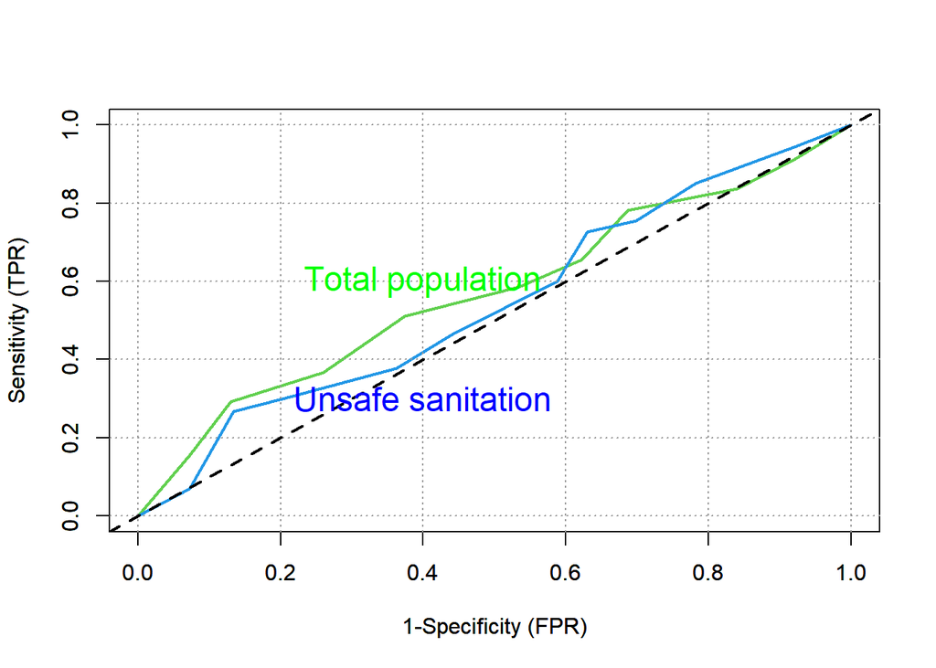

```r
# colour_id 1-7 are: black,red,green,blue,cyan,purple,gold
plot_roc(dCal$pred.total.population, dCal[,outcome], colour_id=3) # population is green
plot_roc(dCal$pred.Unsafe.sanitation, dCal[,outcome], colour_id=4, overlaid=T) #  sanitation is blue
text(x = 0.4, y = 0.6, 'Total population', col = 'green', cex= 1.5)
text(x = 0.4, y = 0.3, 'Unsafe sanitation', col = 'blue', cex = 1.5)
```

It is clear that total population covers a larger area. Let us check the double density plot before drawing conclusion on which numerical variable does the best.

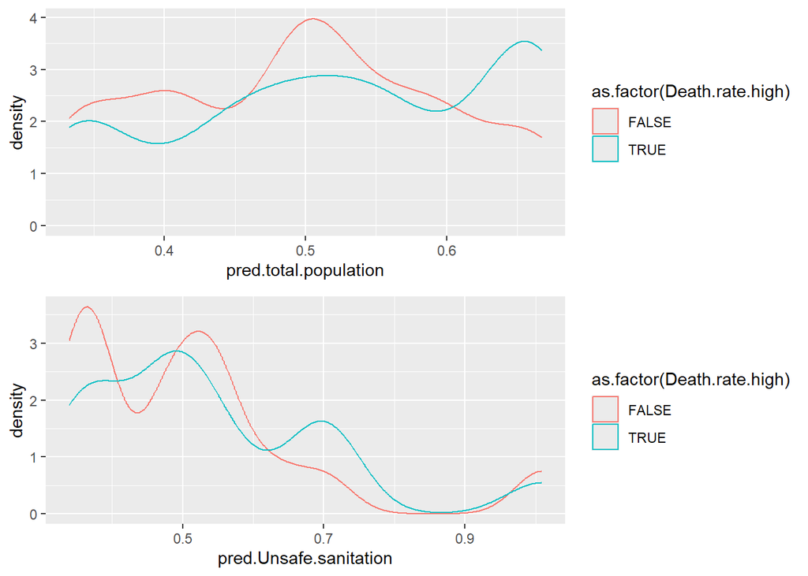

```r
fig1 <- ggplot(dCal) + geom_density(aes(x=pred.total.population, color=as.factor(Death.rate.high)))

fig2 <- ggplot(dCal) + geom_density(aes(x=pred.Unsafe.sanitation, color=as.factor(Death.rate.high)))

grid.arrange(fig1, fig2, ncol=1)
```

The peaks for pred.total.population are a bit further away between TRUE and FALSE. When pred.total.population is 0.5 the outcome will likely be False. When it becomes larger than 0.6 more Death.rate.high will be True. This separation helps more in prediction.

In contrast, the peaks of pred.Unsafe.sanitation for True/False are only marginally separated. It is harder to see when which binary value will more likely to appear. Therefore in this round of comparison pred.total.population seems a better choice.

### Conclusion single variable selection

Our interpretation is that the higher the population the higher death rate will likely be. This may reflect the fact that developing countries usually have larger population than highly developed countries, where standards of living is higher and death rate is lower.

Next to that, safe sanitation seems to be crucial. This is more about hand washing, clean environment and hygiene, which are among the very basic needs for living. If these basics are not met, then many other things can go wrong which can push up the death rate.

In addition, according to [WHO stats on 2019](https://ourworldindata.org/grapher/mortality-rate-attributable-to-wash#:~:text=Death%20rate%20attributed%20to%20unsafe,people%20of%20a%20given%20population), the higher death rate by unsafe water, sanitation and lack of hygiene comes mostly from developing countries in Africa, Asia and South America.

[figure not shown]

We will take these selected feature variables into the next round, feed them to multi-variate models to see if using multiple rather than single features can do a better job.

## Naive Bayers model

We will first put selected numeric variables in Naive Nayers model for prediction.

```r
run_nbPred <- function(outcome, selVars){

  pPos <- sum(dTrain[,outcome]==pos)/length(dTrain[,outcome])

  nBayes <- function(pPos, pf) {
    pNeg <- 1 - pPos
    smoothingEpsilon <- 1.0e-5
    scorePos <- log(pPos + smoothingEpsilon) +
      rowSums(log(pf/pPos + smoothingEpsilon))
    scoreNeg <- log(pNeg + smoothingEpsilon) +
      rowSums(log((1-pf)/(1-pPos) + smoothingEpsilon))
    m <- pmax(scorePos, scoreNeg)
    expScorePos <- exp(scorePos-m)
    expScoreNeg <- exp(scoreNeg-m)
    expScorePos/(expScorePos+expScoreNeg)
  }

  dTrain$nbpredl <- nBayes(pPos, dTrain[,selVars])
  dCal$nbpredl <- nBayes(pPos, dCal[,selVars])
  dTest$nbpredl <- nBayes(pPos, dTest[,selVars])

  # it seems the nbpredl has still NaN values. We will impute them with the median
  dTrain <- dTrain %>%
    mutate(nbpredl = ifelse(is.na(nbpredl), median(nbpredl, na.rm = TRUE), nbpredl))
  dCal <- dCal %>%
    mutate(nbpredl = ifelse(is.na(nbpredl), median(nbpredl, na.rm = TRUE), nbpredl))
  dTest <- dTest %>%
    mutate(nbpredl = ifelse(is.na(nbpredl), median(nbpredl, na.rm = TRUE), nbpredl))

  cat('Input variables are:', selVars, '\n')
  cat('The AUC value for the training set is:', calcAUC(dTrain$nbpredl, dTrain[,outcome]==pos), '\n')
  #The AUC value for the training set for uws and hapfsf is: 0.5575

  cat('The AUC value for the calibration set is:', calcAUC(dCal$nbpredl, dCal[,outcome]==pos), '\n')

  cat('The AUC value for the test set is:', calcAUC(dTest$nbpredl, dTest[,outcome]==pos))
}

#include also in NB model
selVars <- selNumVars #c(selCatVars, selNumVars[2])
run_nbPred(outcome, selVars)
```

```
## Input variables are: pred.total.population pred.Unsafe.sanitation
## The AUC value for the training set is: 0.560732
## The AUC value for the calibration set is: 0.5764207
## The AUC value for the test set is: 0.5086299
```

Just to review, in the single variable prediction pred.total.population had AUC:

- 0.533 for training
- 0.571 for calibration
- 0.529 for test.

pred.Unsafe.sanitation had AUC

- 0.558 for training,
- 0.545 for calibration
- 0.493 for test.

```r
selVars <- selCatVars
run_nbPred(outcome, selVars)
```

```
## Input variables are: pred.Unsafe.sex.over.median pred.Smoking.over.median pred.Blood.pressure.over.median
## The AUC value for the training set is: 0.5
## The AUC value for the calibration set is: 0.5
## The AUC value for the test set is: 0.507023
```

Similar to what we noticed earlier, these variables do not really contribute to better prediction. Naive Bayers model is useful for predictions with many input variables and categorical variables with many levels. Since our categorical variables only contain 2 values true/false, they don’t really improve the performance. We are going to try again with *Country* and *Year* as extra categorical variables which have many more levels.

```r
selVars <- c(selVars, 'pred.Country', 'pred.Year')
run_nbPred(outcome, selVars)
```

```
## Input variables are: pred.Unsafe.sex.over.median pred.Smoking.over.median pred.Blood.pressure.over.median pred.Country pred.Year
## The AUC value for the training set is: 0.5459103
## The AUC value for the calibration set is: 0.568151
## The AUC value for the test set is: 0.5411145
```

Note the AUC score is getting better. Now run NB model with all selected categorical and top performing numerical variables.

```r
selVars <- c(selVars, selNumVars)
run_nbPred(outcome, selVars)
```

```
## Input variables are: pred.Unsafe.sex.over.median pred.Smoking.over.median pred.Blood.pressure.over.median pred.Country pred.Year pred.total.population pred.Unsafe.sanitation
## The AUC value for the training set is: 0.5701795
## The AUC value for the calibration set is: 0.6002332
## The AUC value for the test set is: 0.5695044
```

It has become 0.6 which is better than the combination of all categorical variables. It is also better than each top performing numerical variables pred.total.population, pred.Unsafe.sanitation alone.

## Decision tree model

We will place the same set of variables from Naive Bayers in the decision tree model using *rpart*. In our first attempt we do not consider *Country* and *Year*.

```r
library(rpart)
library(rpart.plot)

selVars <- c(selCatVars, selNumVars)

fV <- paste(outcome, '>0 ~ ', paste(selVars, collapse=' + '), sep='')
print(fV)
```

```
## [1] "Death.rate.high>0 ~ pred.Unsafe.sex.over.median + pred.Smoking.over.median + pred.Blood.pressure.over.median + pred.total.population + pred.Unsafe.sanitation"
```

```r
tmodel <- rpart(formula = fV, data=dTrain)
cat(' The AUC for training set is: ', calcAUC(predict(tmodel, newdata=dTrain), dTrain[,outcome]), '\n The AUC for calibration set is :', calcAUC(predict(tmodel, newdata=dCal), dCal[,outcome]), '\n The AUC for test set is: ', calcAUC(predict(tmodel, newdata=dTest), dTest[,outcome]))
```

```
##  The AUC for training set is:  0.705922
##  The AUC for calibration set is : 0.6935539
##  The AUC for test set is:  0.6825181
```

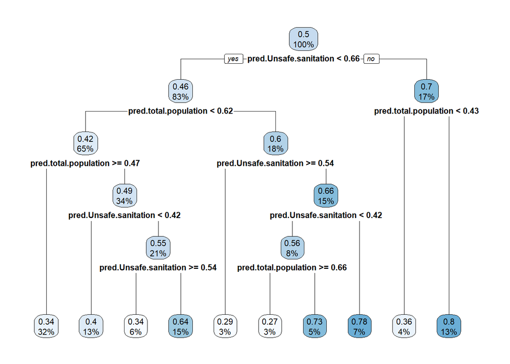

```r
rpart.plot(tmodel)
```

This is a much better outcome than the Naive Bayers, reaching 0.70 for training dataset with nearly consistent performance for calibration and test sets.

Now include the *Country* and *Year* to see if there are any improvements.

```r
selVars <- c(selCatVars, 'pred.Country', 'pred.Year', selNumVars)

fV <- paste(outcome, '>0 ~ ', paste(selVars, collapse=' + '), sep='')
print(fV)
```

```
## [1] "Death.rate.high>0 ~ pred.Unsafe.sex.over.median + pred.Smoking.over.median + pred.Blood.pressure.over.median + pred.Country + pred.Year + pred.total.population + pred.Unsafe.sanitation"
```

```r
tmodel <- rpart(formula = fV, data=dTrain)
cat(' The AUC for training set is: ', calcAUC(predict(tmodel, newdata=dTrain), dTrain[,outcome]), '\n The AUC for calibration set is :', calcAUC(predict(tmodel, newdata=dCal), dCal[,outcome]), '\n The AUC for test set is: ', calcAUC(predict(tmodel, newdata=dTest), dTest[,outcome]))
```

```
##  The AUC for training set is:  0.8154215
##  The AUC for calibration set is : 0.8125742
##  The AUC for test set is:  0.8118982
```

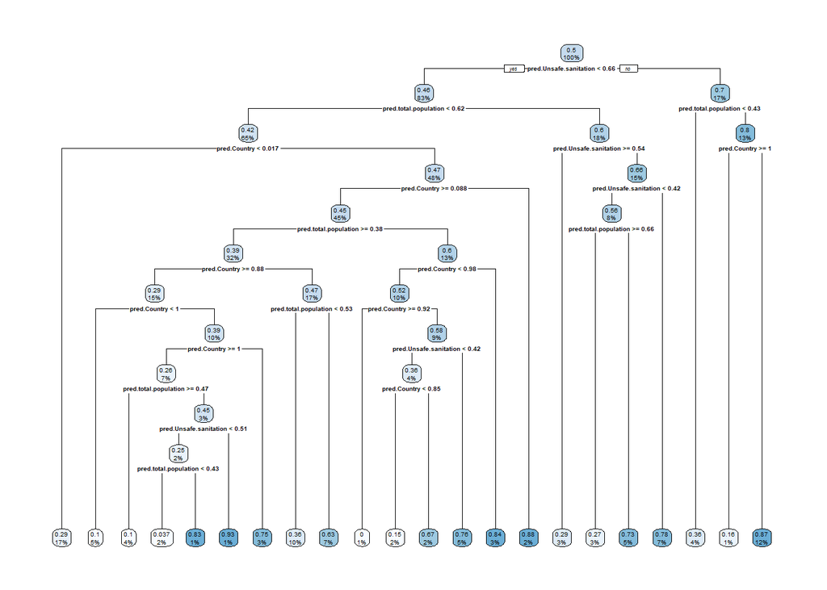

```r
rpart.plot(tmodel)
```

The AUC increases to over 0.81 across training, calibration and test data. This is the highest score so far which is way better than single variable and Naive Bayers.

Our interpretation is that the high death rate is also dependent on year and country. This makes sense when comparing livability across countries and across a period of time. Highly developed countries tend to offer better places for life. In the meantime, some developing countries were also in the transitional phase where improvements to their economy and general standard for living took place in the years between 1990 and 2019.

## Clustering

We would like to pick diet related death causes for exploration in this section. As the total number of countries (>200) is unreadable when visualising hierarchical structure in this report, we will only choose 25 of them. More specifically, we would like to focus on year 2000 which is the turn of the century. We will start with 5 clusters.

```r
set.seed(123)
uCons <- unique(df_merged$Country)

clusterSet <- df_merged[df_merged$Year == 2000, ]

clusterSet <- clusterSet[sample(length(uCons), size = 25, replace = F), ]

vars.to.use <- c('Diet.low.in.whole.grains.rate', 'Diet.low.in.fruits.rate', 'Diet.low.in.Vegetables.rate', 'Diet.low.in.nuts.and.seeds.rate', 'Diet.high.in.sodium.rate')

scaled_df <- scale(clusterSet[, vars.to.use]) # this is a matrix

# The scaled:center attribute contains the mean values of all the columns.
print(attr(scaled_df, "scaled:center"))
```

```
##   Diet.low.in.whole.grains.rate         Diet.low.in.fruits.rate
##                     0.036022212                     0.016434108
##     Diet.low.in.Vegetables.rate Diet.low.in.nuts.and.seeds.rate
##                     0.012717998                     0.009996653
##        Diet.high.in.sodium.rate
##                     0.027834230
```

```r
# The scaled:scale attribute contains the variances of all the columns.
print(attr(scaled_df, "scaled:scale"))
```

```
##   Diet.low.in.whole.grains.rate         Diet.low.in.fruits.rate
##                     0.018510931                     0.006347628
##     Diet.low.in.Vegetables.rate Diet.low.in.nuts.and.seeds.rate
##                     0.006975479                     0.008648351
##        Diet.high.in.sodium.rate
##                     0.019053714
```

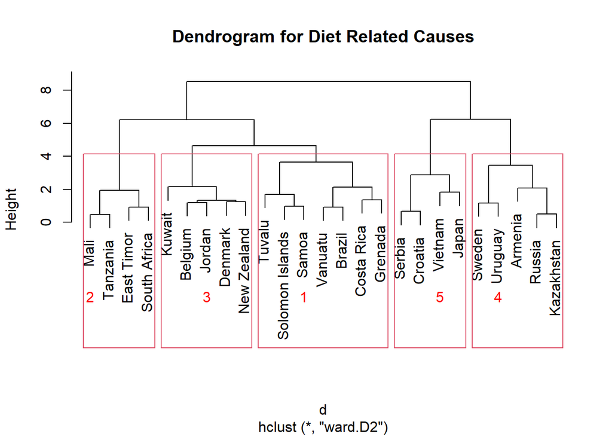

```r
d <- dist(scaled_df, method="euclidean")
pfit <- hclust(d, method="ward.D2")

# To examine `pfit`, type: summary(pfit) and pfit$height
plot(pfit, labels=clusterSet$Country, main="Dendrogram for Diet Related Causes")
rect.hclust(pfit, k=5) # k=5 means we want rectangles to be put around 5 clusters
xx <- c(1, 7, 12, 19, 22)
yy <- -4.5
clusterID <- c(2,3,1,5,4)
text(xx, yy, clusterID, col="red")
```

In this cluster dendrogram some countries within the same cluster are geographically closer to others. For example, in cluster 2 South Africa, Tanzania and Mali are all in Africa. In cluster 3, Denmark and Belgium are two European countries. In cluster 5, Serbia and Croatia are neighbors. In cluster 1, Tuvalu, Solomon Islands, Samoa and Vanuatu are all island countries from Oceania.

Our interpretation is that countries from the same region share similar dietary habits, and therefore people tend to die from similar causes. This clustering does show some pattern related to geographical proximity, although we are not sure yet if $k=5$ is the best option. Now we will visualise the clusters with 2 principle components.

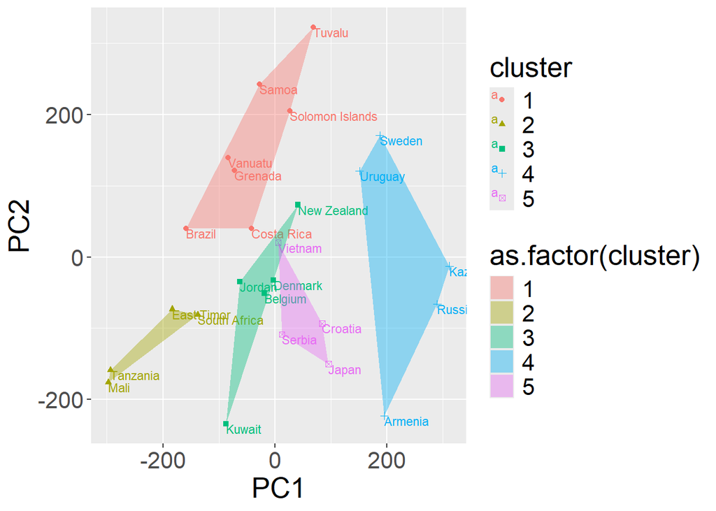

```r
# Calculate the principal components of scaled_df
princ <- prcomp(scaled_df)
nComp <- 2 # focus on the first two principal components

# project scaled_df onto the first 2 principal components to form a new
# 2-column data frame.
project2D <- as.data.frame(predict(princ, newdata=scaled_df)[,1:nComp])

# combine with `groups` and clusterSet$Country to form a 4-column data frame
hclust.project2D <- cbind(project2D, cluster=as.factor(groups), country=clusterSet$Country)

# finding convex hull
find_convex_hull <- function(proj2Ddf, groups) {
  do.call(rbind,
          lapply(unique(groups),
                 FUN = function(c) {
                   f <- subset(proj2Ddf, cluster==c);
                   f[chull(f),]
                 }
          )
  )
}
hclust.hull <- find_convex_hull(hclust.project2D, groups)

fig_hclust <- ggplot(hclust.project2D, aes(x=PC1, y=PC2)) +
  geom_point(aes(shape=cluster, color=cluster)) +
  geom_text(aes(label=country, color=cluster), hjust=0, vjust=1, size=3) +
  geom_polygon(data=hclust.hull, aes(group=cluster, fill=as.factor(cluster)),
               alpha=0.4, linetype=0) + theme(text=element_text(size=20))

print(fig_hclust)
```

The ideal clustering result is when all points within a cluster are very close to each other (small distance within a cluster), and large distance between different clusters. Notice group 1, 2 and 4 are quite separated from each other while 3 and 5 seems to be close or even intersecting each other. Probably $k=5$ is not the best option.

Now it is time to use measurements to see if we can spot a better k. We will use within sum of squares (WSS), total sum of squares (TSS), between sum of squares (BSS) to calculate Calinski-Harabasz index (CH index)

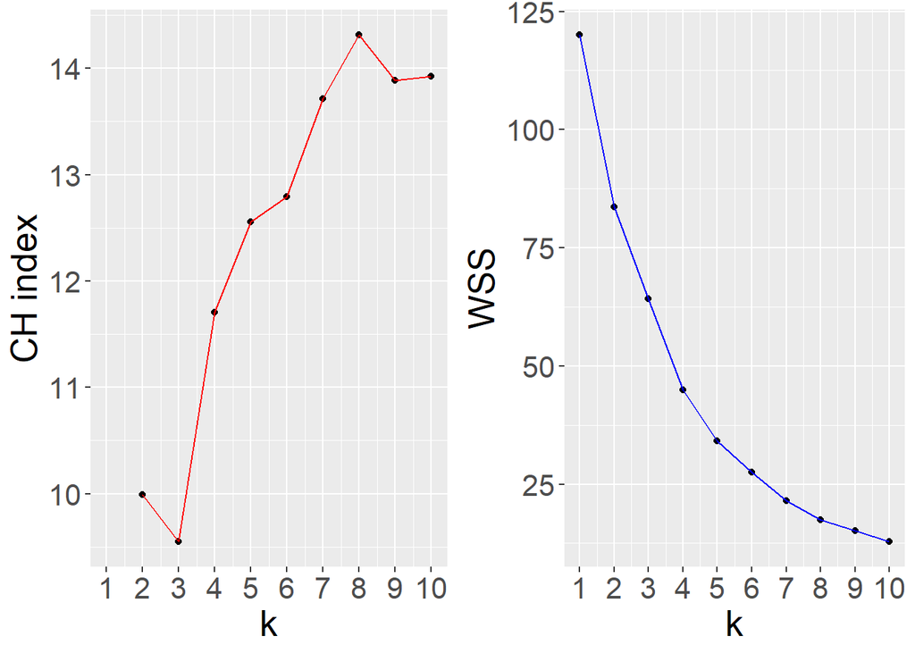

```r
sqr_euDist <- function(x, y) {
  sum((x - y)^2)
}

# Function to calculate WSS of a cluster, represented as a n-by-d matrix
# (where n and d are the numbers of rows and columns of the matrix)
# which contains only points of the cluster.
wss <- function(clustermat) {
  c0 <- colMeans(clustermat)
  sum(apply( clustermat, 1, FUN=function(row) {sqr_euDist(row, c0)} ))
}

# Function to calculate the total WSS. Argument `scaled_df`: data frame
# with normalised numerical columns. Argument `labels`: vector containing
# the cluster ID (starting at 1) for each row of the data frame.
wss_total <- function(scaled_df, labels) {
  wss.sum <- 0
  k <- length(unique(labels))
  for (i in 1:k)
    wss.sum <- wss.sum + wss(subset(scaled_df, labels == i))
  wss.sum
}

# Function to calculate total sum of squared (TSS) distance of data
# points about the (global) mean. This is the same as WSS when the
# number of clusters (k) is 1.
tss <- function(scaled_df) {
  wss(scaled_df)
}
# Function to return the CH indices computed using hierarchical
# clustering (function `hclust`) or k-means clustering (`kmeans`)
# for a vector of k values ranging from 1 to kmax.
CH_index <- function(scaled_df, kmax, method="kmeans") {
  if (!(method %in% c("kmeans", "hclust")))
    stop("method must be one of c('kmeans', 'hclust')")
  npts <- nrow(scaled_df)
  wss.value <- numeric(kmax) # create a vector of numeric type
  # wss.value[1] stores the WSS value for k=1 (when all the
  # data points form 1 large cluster).
  wss.value[1] <- wss(scaled_df)
  if (method == "kmeans") {
    # kmeans
    for (k in 2:kmax) {
      clustering <- kmeans(scaled_df, k, nstart=10, iter.max=100)
      wss.value[k] <- clustering$tot.withinss
    }
  } else {
    # hclust
    d <- dist(scaled_df, method="euclidean")
    pfit <- hclust(d, method="ward.D2")
    for (k in 2:kmax) {
      labels <- cutree(pfit, k=k)
      wss.value[k] <- wss_total(scaled_df, labels)
    }
  }
  bss.value <- tss(scaled_df) - wss.value # this is a vector
  B <- bss.value / (0:(kmax-1)) # also a vector
  W <- wss.value / (npts - 1:kmax) # also a vector
  data.frame(k = 1:kmax, CH_index = B/W, WSS = wss.value)
}

# calculate the CH criterion
crit.df <- CH_index(scaled_df, 10, method="hclust")

fig1 <- ggplot(crit.df, aes(x=k, y=CH_index)) +
  geom_point() + geom_line(colour="red") +
  scale_x_continuous(breaks=1:10, labels=1:10) +
  labs(y="CH index") + theme(text=element_text(size=20))
fig2 <- ggplot(crit.df, aes(x=k, y=WSS), color="blue") +
  geom_point() + geom_line(colour="blue") +
  scale_x_continuous(breaks=1:10, labels=1:10) +
  theme(text=element_text(size=20))

grid.arrange(fig1, fig2, nrow=1)
```

Given 25 countries selected randomly, the CH index has the highest value when $k=8$, with local maximum observed at $k=2$. Let us plot the hierarchical clustering again with this $k=8$.

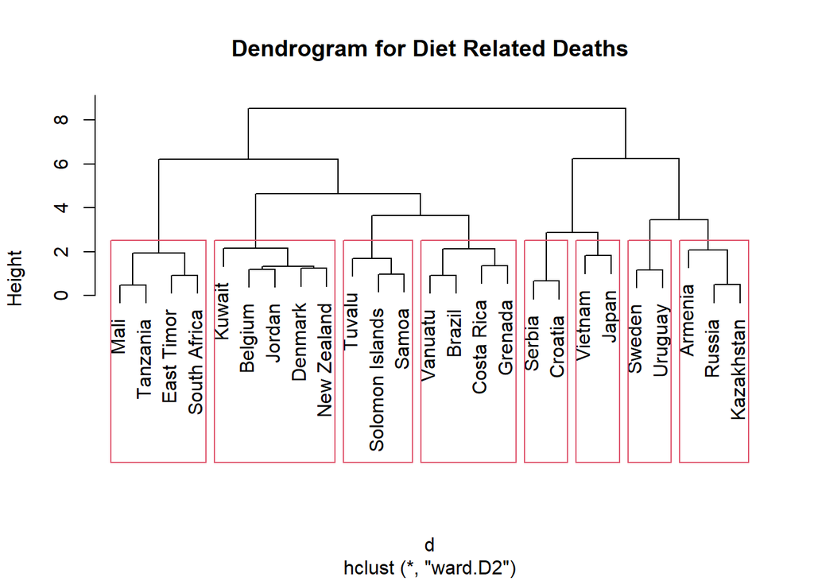

```r
plot(pfit, labels=clusterSet$Country, main="Dendrogram for Diet Related Deaths")
rect.hclust(pfit, k=8)
```

In this dendrogram the pattern is clearer than the previous one in that neighbour countries form separate clusters of their own. See Serbia - Croatia, Vietnam - Japan (both from Asian), Armenia - Russian - Kazakhstan and three islands in Oceania.

Next we will compare this performance with kmeans clustering and see if the best k value changes.

```r
kbest.p <- 5
# run kmeans with 5 clusters, 100 random starts, and 100
# maximum iterations per run.
kmClusters <- kmeans(scaled_df, kbest.p, nstart=100, iter.max=100)

kmClustering.ch <- kmeansruns(scaled_df, krange=1:10, criterion="ch")

kmClustering.asw <- kmeansruns(scaled_df, krange=1:10, criterion="asw")

hclusting <- CH_index(scaled_df, 10, method="hclust")
cat("CH index from hclust for k=1 to 10:/n", hclusting$CH_index)
```

```
## CH index from hclust for k=1 to 10:/n NaN 9.988806 9.548892 11.70504 12.55628 12.79055 13.71167 14.3129 13.88673 13.92565
```

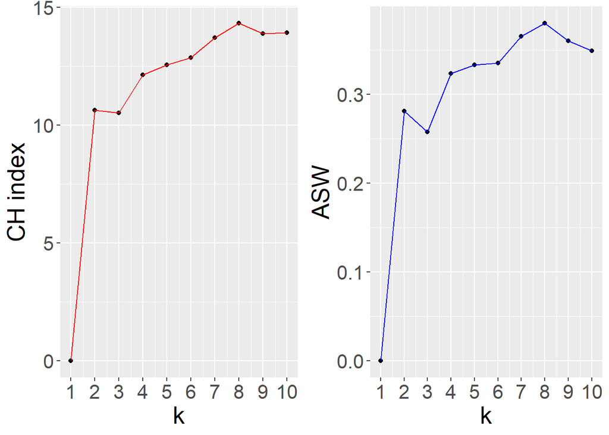

```r
kmCritframe <- data.frame(k=1:10, ch=kmClustering.ch$crit,
                          asw=kmClustering.asw$crit)

fig1 <- ggplot(kmCritframe, aes(x=k, y=ch)) +
  geom_point() + geom_line(colour="red") +
  scale_x_continuous(breaks=1:10, labels=1:10) +
  labs(y="CH index") + theme(text=element_text(size=20))

fig2 <- ggplot(kmCritframe, aes(x=k, y=asw)) +
  geom_point() + geom_line(colour="blue") +
  scale_x_continuous(breaks=1:10, labels=1:10) +
  labs(y="ASW") + theme(text=element_text(size=20))
grid.arrange(fig1, fig2, nrow=1)
```

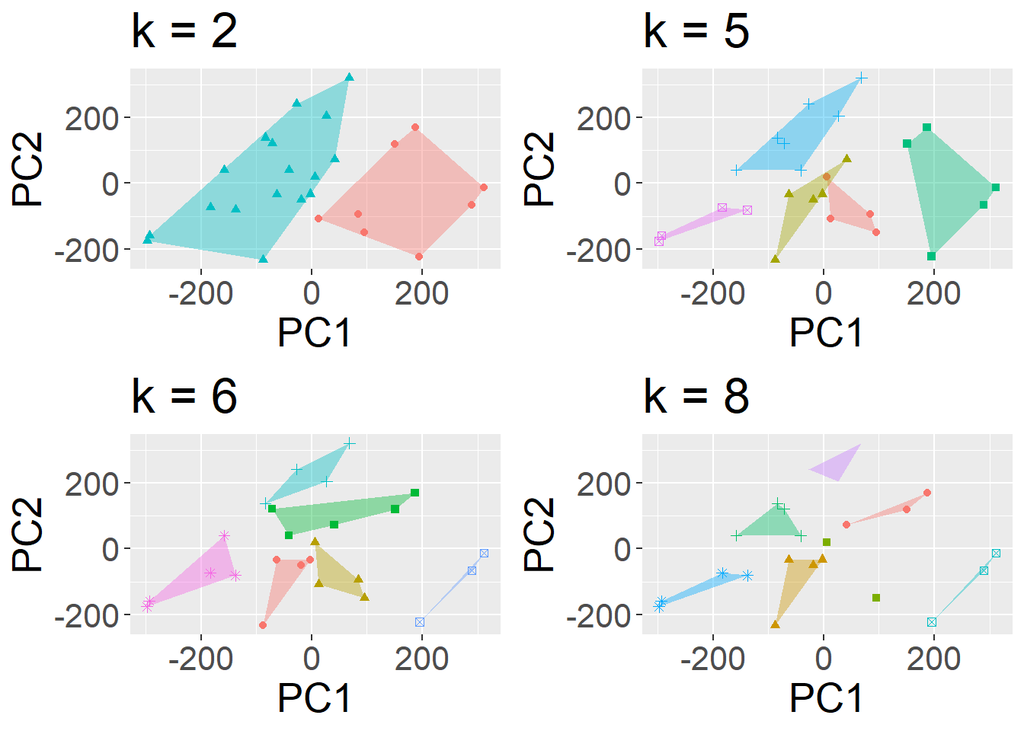

```r
fig <- c()
kvalues <- c(2,5,6,8)
for (k in kvalues) {
  groups <- kmeans(scaled_df, k, nstart=100, iter.max=100)$cluster
  kmclust.project2D <- cbind(project2D, cluster=as.factor(groups),
                             country=df$Country)
  kmclust.hull <- find_convex_hull(kmclust.project2D, groups)
  assign(paste0("fig", k),
         ggplot(kmclust.project2D, aes(x=PC1, y=PC2)) +
           geom_point(aes(shape=cluster, color=cluster)) +
           geom_polygon(data=kmclust.hull, aes(group=cluster, fill=cluster),
                        alpha=0.4, linetype=0) +
           labs(title = sprintf("k = %d", k)) +
           theme(legend.position="none", text=element_text(size=20))
  )
}

grid.arrange(fig2, fig5, fig6, fig8, nrow=2)
```

Both CH index and average silhouette width (ASW) show a local maximum when $k=2$ and a highest value when $k=8$. This is in line with the observation from the hierarchical clustering. We can see in the visual comparison that clusters are farer apart from each other when $k=8$ than when k has other values. Therefore in this round of kmeans clustering 8 is also the best k value.

### LIME evaluation

In this section we would like to understand our predictions with local interpretable model-agnostic explanations (LIME). Firstly, we will use the generalised linear model (glm) to predict our outcome Death.rate.high. We will take all (numeric) variables in this section.

```r
dTrain$class <- as.numeric(dTrain[outcome] == TRUE)
dTest$class <- as.numeric(dTest[outcome] == TRUE)
dCal$class <- as.numeric(dCal[outcome] == TRUE)
pos <- 1

set.seed(12345)

# variables holding truth
#responses <- colnames(dTrain) %in% c(outcome, "class")
features <- numericVars[numericVars != 'Death.rate'] # colnames(dTrain)[!responses] # gsub("^pred\\.", "", selVars)

formula <- paste("class", paste(features, collapse=" + "), sep=" ~ ")
# print(formula)

model_logr <- glm(formula=formula, data=dTrain, family=binomial(link="logit"))

dTrain$pred <- predict(model_logr, newdata=dTrain, type="response")
dTest$pred <- predict(model_logr, newdata=dTest, type="response")
dCal$pred <- predict(model_logr, newdata=dCal, type="response")

# ytrue should be a vector containing 1s (or TRUE) and 0s (or FALSE);
# ypred should be a vector containing the predicted probability values for the target class.
# Both ytrue and ypred should have the same length.
performanceMeasures <- function(ytrue, ypred, model.name = "model", threshold=0.5) {
  # compute the normalised deviance
  dev.norm <- -2 * logLikelihood(ytrue, ypred)/length(ypred)
  cmat <- table(actual = ytrue, predicted = ypred >= threshold)
  accuracy <- sum(diag(cmat)) / sum(cmat)
  precision <- cmat[2, 2] / sum(cmat[, 2])
  recall <- cmat[2, 2] / sum(cmat[2, ])
  f1 <- 2 * precision * recall / (precision + recall)
  data.frame(model = model.name, precision = precision, recall = recall,
             f1 = f1, dev.norm = dev.norm)
}

# create confusion_matrix
confusion_matrix <- function(ytrue, ypred, threshold=0.5) {
  # compute the confusion matrix
  cmat <- table(actual = ytrue, predicted = ypred >= threshold)
  cmat
}

cases <- sample(nrow(dTest), size = 4)
print(dTest[cases, c("class","pred")])
```

```
##      class         pred
## 1627     1 1.000000e+00
## 551      0 2.220446e-16
## 2411     0 2.220446e-16
## 3719     0 1.000000e+00
```

```r
cm <- confusion_matrix(dTest$class, dTest$pred)
print(cm)
```

```
##       predicted
## actual FALSE TRUE
##      0   242   50
##      1    53  223
```

```r
print(performanceMeasures(dTest$class, dTest$pred, 'Logit Test'))
```

```
##        model precision   recall        f1 dev.norm
## 1 Logit Test 0.8168498 0.807971 0.8123862      Inf
```

```r
print(performanceMeasures(dCal$class, dCal$pred, 'Logit Calibration'))
```

```
##               model precision    recall        f1 dev.norm
## 1 Logit Calibration 0.8145455 0.8296296 0.8220183      Inf
```

```r
cat(' AUC for training set in logit: ', calcAUC(predict(model_logr, newdata=dTrain), dTrain[,outcome]), '\n AUC of test set in logit: ', calcAUC(predict(model_logr, newdata=dTest), dTest[,outcome]), '\n AUC for calibration set in logit: ', calcAUC(predict(model_logr, newdata=dCal), dCal[,outcome]))
```

```
##  AUC for training set in logit:  0.9052437
##  AUC of test set in logit:  0.8954115
##  AUC for calibration set in logit:  0.8944586
```

Notice that based on all numeric variables, glm gives AUC values of 0.89 - 0.90. This is much higher than the AUC values (around 0.81) of selected variables with Decision Tree Model. This is a confirmation that logistic regression model is the go-to classifier when predicting binary outcome, which is our case here.

Now we are curious which numeric variable actually contributes the most to this higher performance. We will create an explainer with the help of LIME and XGBoost below.

```r
# Input:
# - variable_matrix: matrix of input data
# - labelvec: numeric vector of class labels (1 is positive class)
#
# Returns:
# - xgboost modelR
fit_mortality_example = function(variable_matrix, labelvec) {
  cv <- xgb.cv(variable_matrix, label = labelvec,
               params=list(
                 objective="binary:logistic"
               ),
               nfold=5,
               nrounds=100,
               print_every_n=10,
               metrics="logloss")

  evalframe <- as.data.frame(cv$evaluation_log)
  NROUNDS <- which.min(evalframe$test_logloss_mean)

  model <- xgboost(data=variable_matrix, label=labelvec,
                   params=list(
                     objective="binary:logistic"
                   ),
                   nrounds=NROUNDS,
                   verbose=FALSE)
  model
}

# Fit the mortality dataset using xgboost:
input <- as.matrix(dTrain[features])
model <- fit_mortality_example(input, dTrain$class)
```

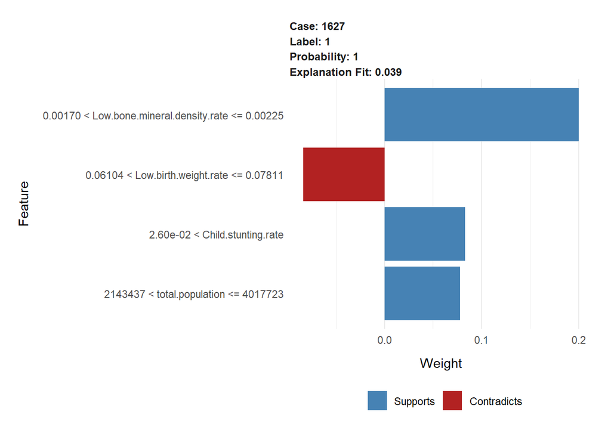

```r
explainer <- lime(dTrain[features], model = model,
                  bin_continuous = TRUE, n_bins = 10)

example <- dTest[cases,features]

explanation1 <- lime::explain(example[1,], explainer, n_labels = 1, n_features = 4)
print(plot_features(explanation1))
```

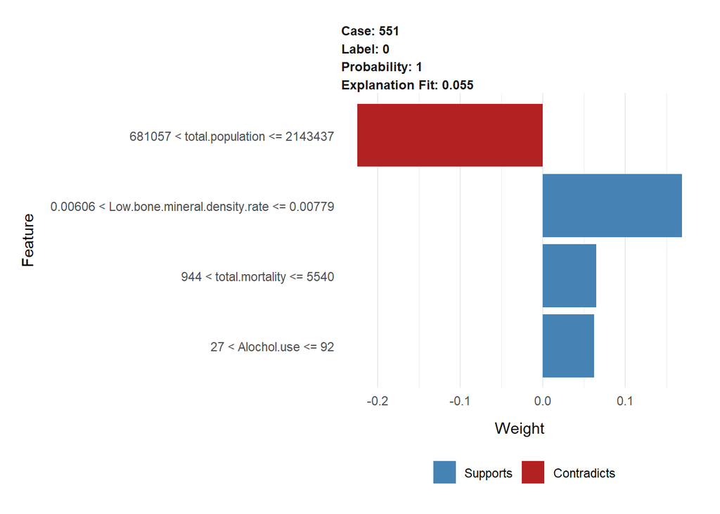

```r
explanation2 <- lime::explain(example[2,], explainer, n_labels = 1, n_features = 4)
print(plot_features(explanation2))
```

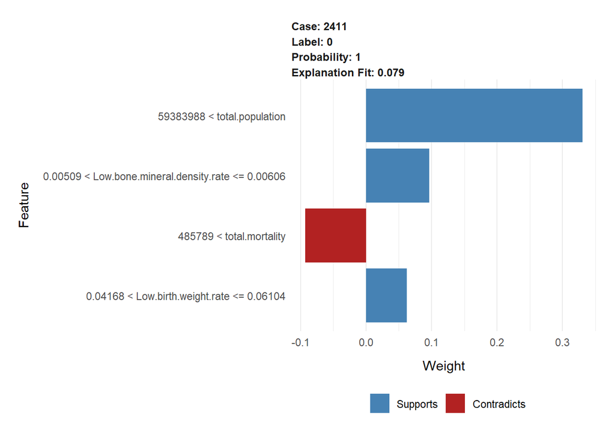

```r
explanation3 <- lime::explain(example[3,], explainer, n_labels = 1, n_features = 4)
print(plot_features(explanation3))
```

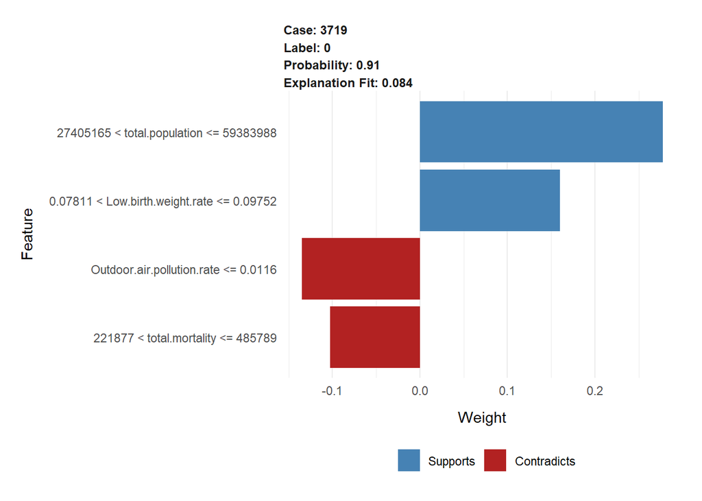

```r
explanation4 <- lime::explain(example[4,], explainer, n_labels = 1, n_features = 4)
print(plot_features(explanation4))
```

On the other hand, low bone mineral density rate and low birth weight rate (how much percent the number of death from these causes cover in total mortality) seem suprisingly useful to our prediction. We do not see the unsafe sanitation back though. Perhaps dying from low mineral density and birth weight (requires the mothers to eat properly) indicate that the food security is not guaranteed. Since food is a bottom line for survival, if food supply is not stable many other problems will occur that cause higher death rates for the whole community.